# Predictors NY

In the following we match external data to our species. 1. Avonet traits [1] 2. Phylogenetic distinctiveness [2,3] 3. IUCN threat status[4] 4. Range geometry 5. Spatial autocorrelation [5] 6. Lacunarity 7. Global range size [6]

Finally, we merge all predictors together.

```r
rm(list=ls())
gc()
```

```
          used (Mb) gc trigger (Mb) max used (Mb)
Ncells  605175 32.4    1378038 73.6   702065 37.5
Vcells 1110908  8.5    8388608 64.0  1927780 14.8
```

```r
suppressPackageStartupMessages({
library(here)
library(dplyr)
library(skimr)
library(readxl)
library(tictoc)

# Phylo distinct
library(ape)
library(phyloregion)

# IUCN
library(taxize)

# Range geometry
library(sf)
library(tidyverse)
library(purrr)
library(terra)
library(broom)
library(geosphere)

# Spatial autocorrelation

library(spdep)
library(rstatix)
# install.packages("spdep", repos = "https://cloud.r-project.org/") # if not installed


})
```

### Paths

```r
data_sf_path <-
  here("Demo_NewYork/Data/output/1_data_sf_ny.rds")

sp_data_path <-
  here("Demo_NewYork/Data/output/1_data_filtered_ny.rds")

tax_path <-
  here("Demo_NewYork/Data/input/Tax_lookup_ny.csv")

avonet_path <-
  here("Demo_NewYork/Data/input/AVONET Supplementary dataset 1.xlsx")

tree_path <-
   here("Demo_NewYork/Data/input/MRC_consensus_BirdTree.tre")
```

### Avonet traits

- Download AVONET Supplementary dataset 1.xlsx here ([[1] Tobias et al. (2022)](https://figshare.com/s/b990722d72a26b5bfead?file=34480856))
- We placed it here: `Demo_NewYork/Data/input/AVONET Supplementary dataset 1.xlsx` (see path above)

```r
#----------------------------------------------------------#
# Load data  -----
#----------------------------------------------------------#

# filtered species list
sci_name <-
  readRDS(sp_data_path) %>%
  distinct(verbatimIdentification, scientificName) # BirdLife 2024 taxonomy

# taxonomic crosswalk with BirdLife 2018 taxonomy as used in Avonet
Tax <-
  read.csv2(tax_path) %>%
  select(verbatimIdentification, scientificName, ScientificName2018)%>%
  filter(verbatimIdentification %in% sci_name$verbatimIdentification) %>%
  distinct(verbatimIdentification, scientificName, .keep_all=TRUE)

# Extract traits from Avonet
traits <-
  readxl::read_excel(avonet_path, sheet = "AVONET1_BirdLife")  %>%
  dplyr::select(
    Species1, Mass,
    Habitat, Migration, Primary.Lifestyle) %>%
  mutate(
    across(c(Habitat, Migration, Primary.Lifestyle),
           as.factor))
# Merge with species names
traits_merged <- traits %>%
  rename("ScientificName2018" = "Species1") %>%
  right_join(Tax) %>%
  select(-ScientificName2018) %>%
  distinct(verbatimIdentification, scientificName, .keep_all = TRUE)
# checks:
traits_merged %>% skimr::skim() # 3 missing
```

Data summary

| Name | Piped data |
| --- | --- |
| Number of rows | 233 |
| Number of columns | 6 |
| _______________________ |  |
| Column type frequency: |  |
| character | 2 |
| factor | 3 |
| numeric | 1 |
| ________________________ |  |
| Group variables | None |

**Variable type: character**

| skim_variable | n_missing | complete_rate | min | max | empty | n_unique | whitespace |
| --- | --- | --- | --- | --- | --- | --- | --- |
| verbatimIdentification | 0 | 1 | 9 | 32 | 0 | 233 | 0 |
| scientificName | 0 | 1 | 9 | 39 | 0 | 233 | 0 |

**Variable type: factor**

| skim_variable | n_missing | complete_rate | ordered | n_unique | top_counts |
| --- | --- | --- | --- | --- | --- |
| Habitat | 3 | 0.99 | FALSE | 9 | For: 90, Wet: 51, Shr: 21, Gra: 20 |
| Migration | 3 | 0.99 | FALSE | 3 | 3: 143, 2: 47, 1: 40, NA: 0 |
| Primary.Lifestyle | 3 | 0.99 | FALSE | 5 | Ins: 98, Ter: 54, Gen: 31, Aer: 27 |

**Variable type: numeric**

| skim_variable | n_missing | complete_rate | mean | sd | p0 | p25 | p50 | p75 | p100 | hist |
| --- | --- | --- | --- | --- | --- | --- | --- | --- | --- | --- |
| Mass | 3 | 0.99 | 324.87 | 747.25 | 3.09 | 14.4 | 47.18 | 334.61 | 5791.37 | ▇▁▁▁▁ |

```r
rm(list = setdiff(ls(),c("data_sf_path","tax_path","sp_data_path","tree_path","sci_name","traits_merged")))
```

### Phylogenetic distinctiveness

This requires the BirdTree [2] tree file, which can be downloaded from [here](https://birdtree.org/). We use the consensus tree that we created based on recommendations from [3]. We placed the tree file here: `Demo_NewYork/Data/input/MRC_consensus_BirdTree.tre` (see path above).

```r
Tax <- read.csv2(tax_path)[2:7] %>%
  filter(verbatimIdentification %in% sci_name$verbatimIdentification)
tree <- read.tree(tree_path)


# pd for all species in the tree
pd <-
  phyloregion::evol_distinct(
  tree,
  type = "fair.proportion",
  scale = FALSE,
  use.branch.lengths = TRUE) %>%
  as.data.frame() %>%
  tibble::rownames_to_column(var = "tip.label") %>%
  rename(pd = ".") %>%
  right_join(Tax) %>%
  select(verbatimIdentification, scientificName, pd) %>%
  filter(verbatimIdentification %in% sci_name$verbatimIdentification) %>%
  distinct(scientificName, verbatimIdentification, .keep_all=T)
# checks
colSums(is.na(pd)) # 3 species not matched
```

```
verbatimIdentification         scientificName                     pd
                     0                      0                      3
```

```r
pd %>%
  filter(is.na(pd)) %>%
  pull(verbatimIdentification)
```

```
[1] "Falcipennis canadensis"           "Anas platyrhynchos x A. rubripes"
[3] "Vermivora chrysoptera x V. pinus"
```

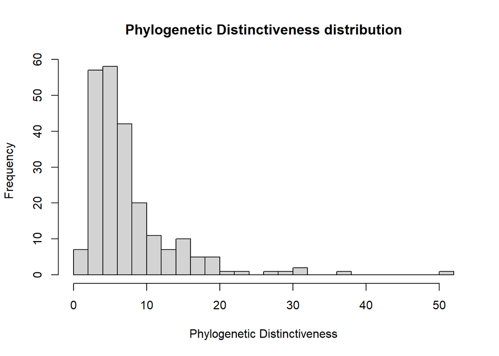

```r
hist(pd$pd, breaks = 30,
  main = "Phylogenetic Distinctiveness distribution",
  xlab = "Phylogenetic Distinctiveness")
```

```r
rm(list = setdiff(ls(),c("data_sf_path","tax_path","sp_data_path","sci_name","traits_merged", "pd")))
```